# Recommender Systems

## Recommender systems - introduction

Motivation for talking about recommender systems:

- Important application of ML systems
- Many technology companies find recommender systems to be absolutely key
- Think about websites (Marktplaats, bol.com, Youtube, etc)
- Try and recommend new content for you based on passed purchase
- Improvement in recommender system performance can bring in more income
- Kind of a funny problem
- In academic learning, recommender systems receives a small amount of attention But in industry it's an absolutely crucial tool

## Example - predict movie ratings

- You're a company who sells movies
- You let users rate movies using a 1-5 star rating
- To make the example nicer, allow 0-5 (makes math easier)
- You have five movies
- And you have four users

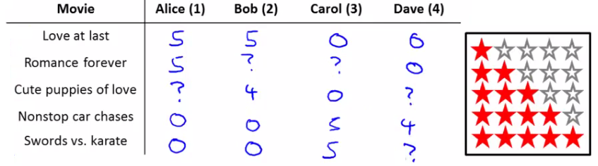

## Example - predict movie ratings

Some notation

- \(n_u\) - Number of users (called ?nu occasionally as we can't subscript in superscript)
- \(n_m\) - Number of movies
- \(r_{(i, j)} = 1\) if user j has rated movie \(i\) (i.e. bitmap)
- \(y_{(i,j)}\) - rating given by user \(j\) to move \(i\) (defined only if \(r_{(i, j)} = 1\) )

So for this example \(n_u = 4\) \(n_m = 5\)

## Summary of scoring

- Alice and Bob gave good ratings to **romance**, but low scores to **action** films
- Carol and Dave game good ratings for **action** films but low ratings for **romance**
- We have the data given above, the problem is as follows

Given \(r_(i,j)\) and \(y_{(i,j)}\) - go through and try and predict missing values (?s) Come up with a learning algorithm that can fill in these missing values

## Content based recommendation

Using our example above, how do we predict?

Suppose that For each movie we have a feature which measure degree to which each film is a

- Romance \(x_1\);
- Action \(x_2\)

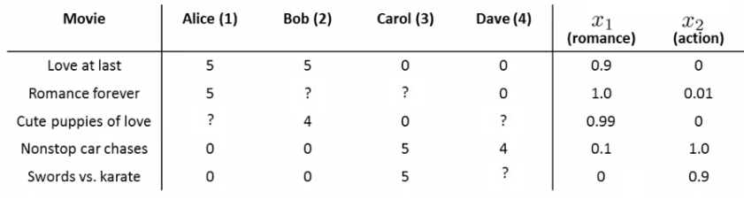

## Content based recommendation

If we have features like these, each film can be recommended by a feature vector Add an extra feature which is \(x_0 = 1\) for each film

## Content based recommendation

We could treat each rating for each user as a separate linear regression problem For each user \(j\) we could learn a parameter vector. Then predict that user \(j\) will rate movie \(i\) with \(θ_j^t.x_i = stars\) inner product of parameter vector and features.

So, lets take user 1 (Alice) and see what she makes of the modern classic Cute Puppies of Love (CPOL)

We have some parameter vector \(θ^1\) associated with Alice \(θ^1=\begin{bmatrix}0 \\ 5 \\ 0\end{bmatrix}\)

We'll explain later how we derived these values, but for now just take it that we have a vector

## Content based recommendation

Our prediction will be equal to \((θ^{1})^t.x^3 = (0 * 1) + (5 * 0.99) + (0 * 0) = 4.95\), Which may seem like a reasonable value

All we're doing here is applying a linear regression method for each user So we determine a future rating based on their interest in romance and action based on previous films

We should also add one final piece of notation: \(m_j\), - Number of movies rated by the user \(j\).

## How do we learn \(θ^j\)

Create some parameters which give values as close as those seen in the data when applied

\[ \min_{θ^j} \frac{1}{2 m^j} \sum_{i: r(i,j)=1}\big((θ^j)^t x^i - y^{(i,j)} \big)^2 \]

Sum over all values of i (all movies the user has used) when \(r(i,j) = 1\) (i.e. all the films that the user has rated)

To make this a little bit clearer you can get rid of the \(m_j\) term (it's just a constant so shouldn't make any difference to minimization)

\[ \min_{θ^j} \frac{1}{2} \sum_{i: r(i,j)=1}\big((θ^j)^t x^i - y^{(i,j)} \big)^2 \]

## Content based recommendation

But for our recommender system we want to learn parameters for all users, so we add an extra summation term to this which means we determine the minimum \(θ^j\) value for every user

\[ \min_{θ^1,...,θ^{n_u}} \frac{1}{2} \sum_{1}^{n_u}\sum_{i: r(i,j)=1}\big((θ^j)^t x^i - y^{(i,j)} \big)^2 \] When we do this as a function of each \(θ^j\) parameter vector you get the parameters for each user So this is our optimization objective -> \(J(θ^1, ..., θ^{n_u})\)

In order to do the minimization we have the gradient descent technique.

This approach is called content-based approach because we assume we have features regarding the content which will help us identify things that make them appealing to a user However, often such features are not available - next we discuss a non-contents based approach!

## Collaborative filtering - overview

- The collaborative filtering algorithm has a very interesting property - does feature learning i.e. it can learn for itself what features it needs to learn
- Recall our original data set above for our five films and four raters
- Here we assume someone had calculated the "romance" and "action" amounts of the films This can be very hard to do in reality
- Often we want more features than just two So - let's change the problem and pretend we have a data set where we don't know any of the features associated with the films

## Collaborative filtering - overview

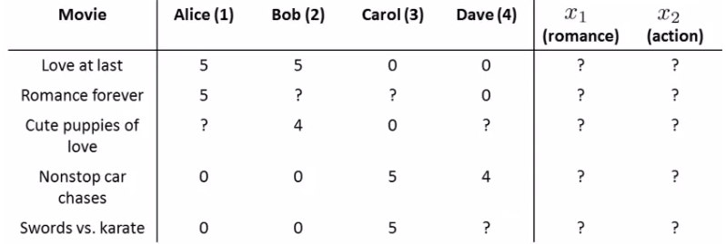

## Collaborative filtering - overview

Now let's make a different assumption

- We've polled each user and found out how much each user likes
- Romantic films
- Action films

Which has generated the following parameter set

\[\theta^1 =\begin{bmatrix}0 \\ 5 \\ 0\end{bmatrix}; \theta^2 =\begin{bmatrix}0 \\ 5 \\ 0\end{bmatrix};\theta^3 =\begin{bmatrix}0 \\ 0 \\ 5\end{bmatrix};\theta^4 =\begin{bmatrix}0 \\ 0 \\ 5\end{bmatrix}\] Alice and Bob like romance but hate action. Carol and Dave like action but hate romance. If we can get these parameters from the users we can infer the missing values from our table

## Collaborative filtering - overview

Lets look at "Love at Last"

- Alice and Bob loved it
- Carol and Dave hated it

We know from the feature vectors Alice and Bob love romantic films, while Carol and Dave hate them Based on the factor Alice and Bob liked "Love at Last" and Carol and Dave hated it we may be able to (correctly) conclude that "Love at Last" is a romantic film

We know from the feature vectors Alice and Bob love romantic films, while Carol and Dave hate them

- Based on the factor Alice and Bob liked "Love at Last" and Carol and Dave hated it we may be able to (correctly) conclude that "Love at Last" is a romantic film

## Collaborative filtering - overview

This is a bit of a simplification in terms of the maths, but what we're really asking is: What feature vector should \(x_1\) be so that:

- \((θ^1)^t.x^1\) is about 5
- \((θ^2)^t.x^1\) is about 5
- \((θ^3)^t.x^1\) is about 0
- \((θ^4)^t.x^1\) is about 0

Using that same approach we should then be able to determine the remaining feature vectors for the other films

## Formalizing the collaborative filtering problem

We can more formally describe the approach as follows:

Given \((\theta_1, ..., \theta_{n_u})\) (i.e. given the parameter vectors for each users' preferences), we should minimize an optimization function which tries to identify the best parameter vector associated with a film

\[ \min_{x^i} \frac{1}{2} \sum_{i: r(i,j)=1}\big((θ^j)^t x^i - y^{(i,j)} \big)^2 \]

So we're summing over all the indices \(j\) for where we have data for movie \(i\)

We're minimizing this squared error

Like before, the above equation gives us a way to learn the features for one film We want to learn all the features for all the films - so we need an additional summation term

## How does this work with the previous recommendation system

- Content based recommendation systems: We saw that if we have a set of features for movie rating you can learn a user's preferences
- Now: If you have your users preferences you can therefore determine a film's features
- This is a bit of a chicken & egg problem
- What we can do is
1. Randomly guess values for \(\theta\)
2. Then use collaborative filtering to generate \(x\)
3. Then use content based recommendation to improve \(\theta\)
4. Use that to improve \(x\), and so on

## How does this work with the previous recommendation system

- This actually works
- Cause the algorithm to converge on a reasonable set of parameters
- This is collaborative filtering
- We call it collaborative filtering because in this example the users are collaborating together to help the algorithm learn better features and help the system and the other users

## Collaborative filtering Algorithm

Here we combine the ideas from before to build a collaborative filtering algorithm. Our starting point is as follows

If we're given the film's features we can use that to work out the users' preference

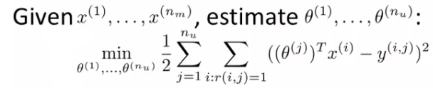

## Collaborative filtering Algorithm

If we're given the users' preferences we can use them to work out the film's features

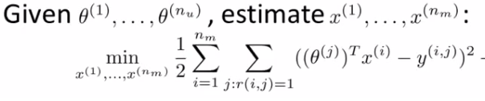

One thing we could do is

- Randomly initialize parameter
- Go back and forward